# Global Early Childhood Education Initiatives: A Data-Driven Exploration

Author

Caitlin McGonagle

# 🌍**Global Early Childhood Education Initiatives: A Data-Driven Exploration**🌍

Education can be regarded as a catalyst for children and their future, yet access remains deeply unequal worldwide. As will be evidenced, *economic conditions, geographical location, societal norms and gender biases* shape the extent to which children receive an educational foundation.

A variety of factors can influence early education programme participation **(among children aged 36-59 months)**. By exploring the data, we can understand how investing early can yield greater benefits for both the child and their environment.

```python
import polars as pl
```

```python
indicator1 = pl.read_csv("unicef_indicator_1.csv")

metadata = pl.read_csv(

     "unicef_metadata.csv",

    schema_overrides={"Population, total": pl.Float64}
)
```

```python
metadata = metadata.rename({"year": "time_period"})
full_data = indicator1.join(metadata, on=["country", "time_period"], how="left")
full_data.head()
```

shape: (5, 27)

| country str | alpha_2_code str | alpha_3_code str | numeric_code i64 | indicator str | time_period i64 | obs_value f64 | sex str | unit_multiplier str | unit_of_measure str | observation_status str | observation_confidentaility str | time_period_activity_related_to_when_the_data_are_collected str | current_age str | alpha_2_code_right str | alpha_3_code_right str | numeric_code_right i64 | Population, total f64 | GDP per capita (constant 2015 US$) f64 | GNI (current US$) f64 | Inflation, consumer prices (annual %) f64 | Life expectancy at birth, total (years) f64 | Military expenditure (% of GDP) f64 | Fossil fuel energy consumption (% of total) f64 | GDP growth (annual %) f64 | Birth rate, crude (per 1,000 people) f64 | Hospital beds (per 1,000 people) f64 |
| --- | --- | --- | --- | --- | --- | --- | --- | --- | --- | --- | --- | --- | --- | --- | --- | --- | --- | --- | --- | --- | --- | --- | --- | --- | --- | --- |
| "Afghanistan" | "AF" | "AFG" | 4 | "Percentage of children aged 36… | 2023 | 0.9 | "Female" | null | "%" | "Reported" | "Free" | "End of fieldwork" | "36 to 59 months old" | "AF" | "AFG" | 4 | 4.1454761e7 | 379.707497 | 1.7315e10 | null | null | null | null | 2.710887 | null | null |
| "Afghanistan" | "AF" | "AFG" | 4 | "Percentage of children aged 36… | 2023 | 1.0 | "Male" | null | "%" | "Reported" | "Free" | "End of fieldwork" | "36 to 59 months old" | "AF" | "AFG" | 4 | 4.1454761e7 | 379.707497 | 1.7315e10 | null | null | null | null | 2.710887 | null | null |
| "Afghanistan" | "AF" | "AFG" | 4 | "Percentage of children aged 36… | 2023 | 0.9 | "Total" | null | "%" | "Reported" | "Free" | "End of fieldwork" | "36 to 59 months old" | "AF" | "AFG" | 4 | 4.1454761e7 | 379.707497 | 1.7315e10 | null | null | null | null | 2.710887 | null | null |
| "Albania" | "AL" | "ALB" | 8 | "Percentage of children aged 36… | 2018 | 72.5 | "Female" | null | "%" | "Reported" | "Free" | "End of fieldwork" | "36 to 59 months old" | "AL" | "ALB" | 8 | 2.866376e6 | 4431.555595 | 1.5361e10 | 2.02806 | 79.184 | 1.160545 | null | 4.019346 | 10.517 | 2.84 |
| "Albania" | "AL" | "ALB" | 8 | "Percentage of children aged 36… | 2018 | 72.5 | "Male" | null | "%" | "Reported" | "Free" | "End of fieldwork" | "36 to 59 months old" | "AL" | "ALB" | 8 | 2.866376e6 | 4431.555595 | 1.5361e10 | 2.02806 | 79.184 | 1.160545 | null | 4.019346 | 10.517 | 2.84 |

```python
import country_converter as coco
continents = coco.convert(names=full_data["country"].to_list(), to="continent")
full_data = full_data.with_columns([


    pl.Series("continent", values=continents)
])

full_data.select(["country", "continent"]).unique()
```

shape: (120, 2)

| country str | continent str |
| --- | --- |
| "Yemen" | "Asia" |
| "Sao Tome and Principe" | "Africa" |
| "Venezuela, Bolivarian Republic… | "America" |
| "Tuvalu" | "Oceania" |
| "Bhutan" | "Asia" |
| … | … |
| "Burkina Faso" | "Africa" |
| "Vietnam" | "Asia" |
| "Nepal" | "Asia" |
| "Angola" | "Africa" |
| "Burundi" | "Africa" |

```python
from plotnine import *
import pandas as pd
```

```python
df = full_data.to_pandas()
df_clean = df.dropna(subset=["continent","obs_value"])
```

```python
bar_data=df_clean.groupby("continent", as_index=False)["obs_value"].mean()
```

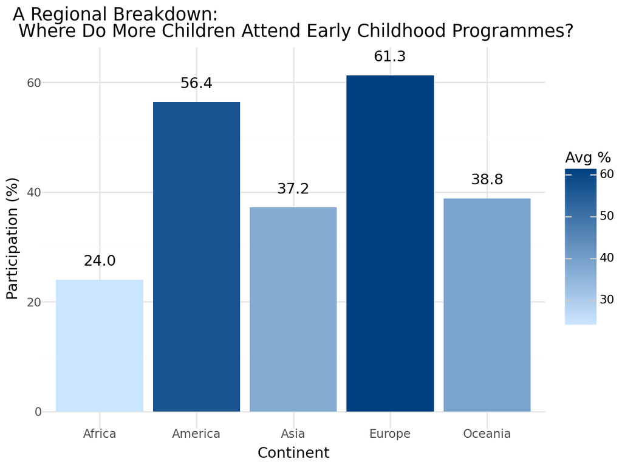

```python
from plotnine import *
import pandas as pd

df = full_data.to_pandas()
df_clean = df.dropna(subset=["continent", "obs_value"])

bar_data = df_clean.groupby("continent", as_index=False)["obs_value"].mean()

(
     ggplot(bar_data, aes(x="continent", y="obs_value", fill="obs_value"))
    +geom_col()
    + geom_text(aes(label=round(bar_data["obs_value"], 1)), va="bottom", nudge_y=2)
+ scale_fill_gradient(low="#cce5ff", high="#004080")


     + labs(
        title="A Regional Breakdown:\n Where Do More Children Attend Early Childhood Programmes?",
         x="Continent",
          y="Participation (%)",
         fill="Avg %"
    )
    +  theme_minimal()
   +  theme(plot_title=element_text(ha='center', va='top'))


)
```

🧠 **This graphic demonstrates the disparate access across world regions to early education initiatives.**

📈 As illustrated, **Europe and South America** lead the landscape with the highest average enrolment rates, suggesting greater investment in or accessibility for the populations of these regions.

⚠️ However, it should be caveated that a number of Western countries are omitted from the dataset for Europe, meaning the continent’s average may not fully reflect the region’s actual performance.

```python
global_time_data = (

    full_data
  .filter(
      pl.col("indicator").str.contains("36") &
        (pl.col("sex") == "Total")
    )
)
```

```python
global_avg = (
  global_time_data
  .group_by("time_period")
    .agg(pl.col("obs_value").mean().alias("avg_participation"))
.sort("time_period")
  .to_pandas()
)
```

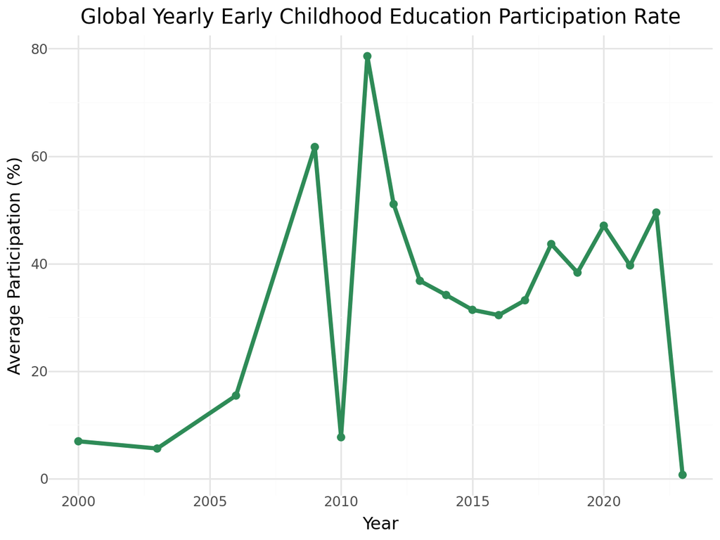

```python
(
    ggplot(global_avg, aes(x="time_period", y="avg_participation"))
    + geom_line(color="#2E8B57", size=1.5)
    + geom_point(color="#2E8B57", size=2)
    + labs(
       title="Global Yearly Early Childhood Education Participation Rate",
       x="Year",
    y="Average Participation (%)"
    )
    + theme_minimal()
)
```

🧠 **The time-series graph illustrates the global average participation rate in education programmes (for children aged 36-59 months), spanning a 23 year time period from 2000 to 2023.**

```python
indicator1 = pl.read_csv("unicef_indicator_1.csv")
metadata = pl.read_csv(

    "unicef_metadata.csv",
    schema_overrides={"Population, total": pl.Float64}
)
```

```python
metadata = metadata.rename({"year": "time_period"})
full_data = indicator1.join(metadata, on=["country", "time_period"], how="left")
```

```python
scatter_data = (
    full_data

    .filter(
        (pl.col("indicator").str.contains("36")) &
        (pl.col("sex") == "Total") &
        pl.col("GDP per capita (constant 2015 US$)").is_not_null() &
        pl.col("obs_value").is_not_null()
    )
  .select(["obs_value", "GDP per capita (constant 2015 US$)", "Population, total", "country"])
   .drop_nulls()
    .to_pandas()
)
```

```python
import matplotlib.pyplot as plt
from sklearn.linear_model import LinearRegression
```

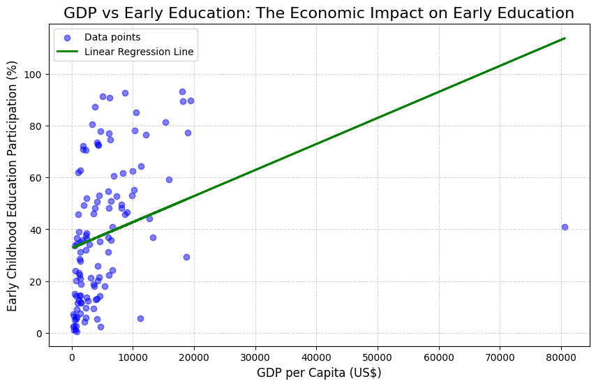

```python
X = scatter_data[["GDP per capita (constant 2015 US$)"]].values

y = scatter_data["obs_value"].values



regressor = LinearRegression()
regressor.fit(X, y)

y_pred = regressor.predict(X)

plt.figure(figsize=(10,6))
plt.scatter(scatter_data["GDP per capita (constant 2015 US$)"], scatter_data["obs_value"], color='blue', label='Data points', alpha=0.5)
plt.plot(scatter_data["GDP per capita (constant 2015 US$)"], y_pred, color='green', label='Linear Regression Line', linewidth=2)
plt.title('GDP vs Early Education: The Economic Impact on Early Education', fontsize=16)
plt.xlabel('GDP per Capita (US$)', fontsize=12)
plt.ylabel('Early Childhood Education Participation (%)', fontsize=12)
plt.legend()
plt.grid(True, linestyle='--', alpha=0.5)
plt.show()
```

## 💡 **HIGHER INVESTMENT = HIGHER RETURNS 💡**

The scatterplot reveals a positive correlation between early childhood education participation and GDP per capita of a country.

Countries with higher rates of participation tend to experience stronger economic performance (in terms of the measure GDP), suggesting that laying the foundation of an educated population can promote economic growth.

However, it should be noted, as demonstrated, some outliers indicate that economic wealth alone doesn’t guarantee early education access, while the relationship is evident, correlation does not imply direct causality

```python
import geopandas as gp
import polars as pl
```

```python
world_map = gp.read_file("https://public.opendatasoft.com/api/explore/v2.1/catalog/datasets/world-administrative-boundaries/exports/shp")
```

```python
indicator1 = pl.read_csv("unicef_indicator_1.csv")

metadata = pl.read_csv(
     "unicef_metadata.csv",

        schema_overrides={"Population, total": pl.Float64}
)
```

```python
metadata = metadata.rename({"year": "time_period"})
full_data = indicator1.join(metadata, on=["country", "time_period"], how="left")
```

```python
world_map_data = full_data.select(["country", "obs_value"]).drop_nulls()
```

```python
merged_data = world_map.merge(world_map_data.to_pandas(), left_on="name", right_on="country", how="outer")
```

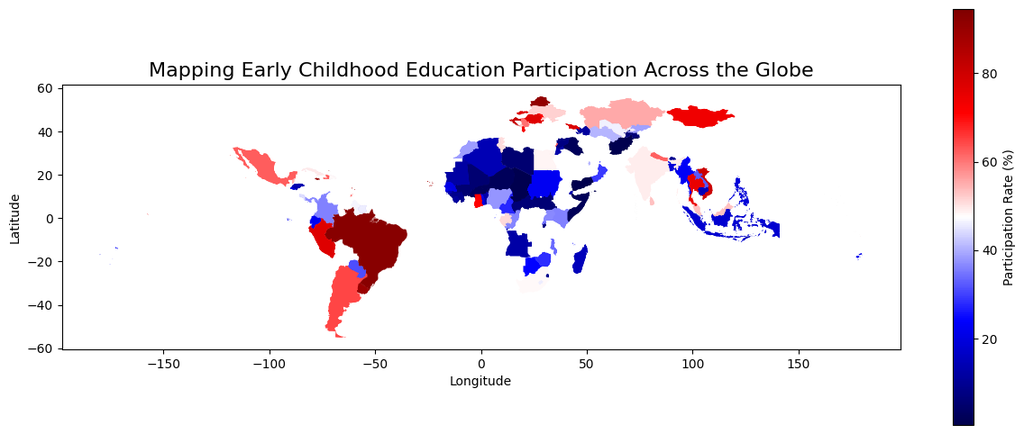

```python
ax = merged_data.plot(
     column="obs_value",
     cmap="seismic",

      legend=True,
      legend_kwds={'label': "Participation Rate (%)"},

     figsize=(15, 6)
)

ax.set_title("Mapping Early Childhood Education Participation Across the Globe", fontsize=16)
ax.set_xlabel("Longitude")
ax.set_ylabel("Latitude")
```

Global education participation varies hugely with trends in participation seen within regions of geographical proximity.

- Higher enrolment **(red)** is experienced in parts of Central Asia, Eastern Europe and South America
- Lower rates of participation **(blue)** can be seen throughout Africa, the Middle East & South Asia.

# **Early education is not just a stepping stone- it’s a global equaliser.**

While any one initiative can not be perfect due to gender, income or geography disparities, the data reinforces a clear message:

🗣Early Investment in the Youth Yields Long-Term Gains for Society 🗣